# HW9

Yongjun Chu

March 11, 2019

```r
#library(tidyverse)
library(ggplot2)
library(dplyr)
library(tidyr)
```

## Question A. Clean and prepare the data:

```r
#upload the two data files: "Beers.csv"" and "Breweries.csv"
beer <- read.csv("C:/Users/chu001/Documents/Yongjun-Chu files/SMU-data-science-application/Doing-Data_Science/Case_study_1/Beers.csv", sep = ',', header = T)
str(beer)
```

```
## 'data.frame':    2410 obs. of  7 variables:
##  $ Name      : Factor w/ 2305 levels "#001 Golden Amber Lager",..: 1638 577 1705 1842 1819 268 1160 758 1093 486 ...
##  $ Beer_ID   : int  1436 2265 2264 2263 2262 2261 2260 2259 2258 2131 ...
##  $ ABV       : num  0.05 0.066 0.071 0.09 0.075 0.077 0.045 0.065 0.055 0.086 ...
##  $ IBU       : int  NA NA NA NA NA NA NA NA NA NA ...
##  $ Brewery_id: int  409 178 178 178 178 178 178 178 178 178 ...
##  $ Style     : Factor w/ 100 levels "","Abbey Single Ale",..: 19 18 16 12 16 80 18 22 18 12 ...
##  $ Ounces    : num  12 12 12 12 12 12 12 12 12 12 ...
```

```r
head(beer)
```

```
##                  Name Beer_ID   ABV IBU Brewery_id
## 1            Pub Beer    1436 0.050  NA        409
## 2         Devil's Cup    2265 0.066  NA        178
## 3 Rise of the Phoenix    2264 0.071  NA        178
## 4            Sinister    2263 0.090  NA        178
## 5       Sex and Candy    2262 0.075  NA        178
## 6        Black Exodus    2261 0.077  NA        178
##                            Style Ounces
## 1            American Pale Lager     12
## 2        American Pale Ale (APA)     12
## 3                   American IPA     12
## 4 American Double / Imperial IPA     12
## 5                   American IPA     12
## 6                  Oatmeal Stout     12
```

```r
#convert all empty or space entries to NA
beer[beer=="" | beer == " "] <- NA
#apply(is.na(beer), 2, which)
sapply(beer, function(x) sum(is.na(x)))
```

```
##       Name    Beer_ID        ABV        IBU Brewery_id      Style
##          0          0         62       1005          0          5
##     Ounces
##          0
```

```r
brewery <- read.csv("C:/Users/chu001/Documents/Yongjun-Chu files/SMU-data-science-application/Doing-Data_Science/Case_study_1/Breweries.csv", sep = ',', header = T)
str(brewery)
```

```
## 'data.frame':    558 obs. of  4 variables:
##  $ Brew_ID: int  1 2 3 4 5 6 7 8 9 10 ...
##  $ Name   : Factor w/ 551 levels "10 Barrel Brewing Company",..: 355 12 266 319 201 136 227 477 59 491 ...
##  $ City   : Factor w/ 384 levels "Abingdon","Abita Springs",..: 228 200 122 299 300 62 91 48 152 136 ...
##  $ State  : Factor w/ 51 levels " AK"," AL"," AR",..: 24 18 20 5 5 41 6 23 23 23 ...
```

```r
head(brewery)
```

```
##   Brew_ID                      Name          City State
## 1       1        NorthGate Brewing    Minneapolis    MN
## 2       2 Against the Grain Brewery    Louisville    KY
## 3       3  Jack's Abby Craft Lagers    Framingham    MA
## 4       4 Mike Hess Brewing Company     San Diego    CA
## 5       5   Fort Point Beer Company San Francisco    CA
## 6       6     COAST Brewing Company    Charleston    SC
```

```r
#convert all empty or space entries to NA
brewery[brewery == "" | brewery == " "] <- NA
sapply(brewery, function(x) sum(is.na(x)))
```

```
## Brew_ID    Name    City   State
##       0       0       0       0
```

```r
#remove the extra empty space before the state name in column State
brewery$State <- as.factor(gsub("^\\s+", "", brewery$State))
str(brewery)
```

```
## 'data.frame':    558 obs. of  4 variables:
##  $ Brew_ID: int  1 2 3 4 5 6 7 8 9 10 ...
##  $ Name   : Factor w/ 551 levels "10 Barrel Brewing Company",..: 355 12 266 319 201 136 227 477 59 491 ...
##  $ City   : Factor w/ 384 levels "Abingdon","Abita Springs",..: 228 200 122 299 300 62 91 48 152 136 ...
##  $ State  : Factor w/ 51 levels "AK","AL","AR",..: 24 18 20 5 5 41 6 23 23 23 ...
```

```r
colnames(beer)[1] <- "Name_beer"
colnames(beer)[5] <- "Brew_ID"
colnames(brewery)[2] <- "Name_brew"
total = merge(beer, brewery, by.x="Brew_ID", by.y="Brew_ID", all = T)
nrow(total)
```

```
## [1] 2410
```

```r
head(total)
```

```
##   Brew_ID     Name_beer Beer_ID   ABV IBU
## 1       1  Get Together    2692 0.045  50
## 2       1 Maggie's Leap    2691 0.049  26
## 3       1    Wall's End    2690 0.048  19
## 4       1       Pumpion    2689 0.060  38
## 5       1    Stronghold    2688 0.060  25
## 6       1   Parapet ESB    2687 0.056  47
##                                 Style Ounces          Name_brew
## 1                        American IPA     16 NorthGate Brewing
## 2                  Milk / Sweet Stout     16 NorthGate Brewing
## 3                   English Brown Ale     16 NorthGate Brewing
## 4                         Pumpkin Ale     16 NorthGate Brewing
## 5                     American Porter     16 NorthGate Brewing
## 6 Extra Special / Strong Bitter (ESB)     16 NorthGate Brewing
##          City State
## 1 Minneapolis    MN
## 2 Minneapolis    MN
## 3 Minneapolis    MN
## 4 Minneapolis    MN
## 5 Minneapolis    MN
## 6 Minneapolis    MN
```

```r
str(total)
```

```
## 'data.frame':    2410 obs. of  10 variables:
##  $ Brew_ID  : int  1 1 1 1 1 1 2 2 2 2 ...
##  $ Name_beer: Factor w/ 2305 levels "#001 Golden Amber Lager",..: 802 1258 2185 1640 1926 1525 458 1218 43 71 ...
##  $ Beer_ID  : int  2692 2691 2690 2689 2688 2687 2686 2685 2684 2683 ...
##  $ ABV      : num  0.045 0.049 0.048 0.06 0.06 0.056 0.08 0.125 0.077 0.042 ...
##  $ IBU      : int  50 26 19 38 25 47 68 80 25 42 ...
##  $ Style    : Factor w/ 100 levels "","Abbey Single Ale",..: 16 77 48 83 22 57 12 46 77 18 ...
##  $ Ounces   : num  16 16 16 16 16 16 16 16 16 16 ...
##  $ Name_brew: Factor w/ 551 levels "10 Barrel Brewing Company",..: 355 355 355 355 355 355 12 12 12 12 ...
##  $ City     : Factor w/ 384 levels "Abingdon","Abita Springs",..: 228 228 228 228 228 228 200 200 200 200 ...
##  $ State    : Factor w/ 51 levels "AK","AL","AR",..: 24 24 24 24 24 24 18 18 18 18 ...
```

```r
#or use this commnad
total1 <- left_join(beer, brewery, by="Brew_ID")
nrow(total1)
```

```
## [1] 2410
```

```r
#Create One Dataset that has only Colorado and Texas beers and no IBU NAs
beerCOTX <- total %>% dplyr::filter((State=="CO"|State=="TX") & !is.na(IBU))
nrow(beerCOTX)
```

```
## [1] 235
```

```r
sapply(beerCOTX, function(x) sum(is.na(x)))
```

```
##   Brew_ID Name_beer   Beer_ID       ABV       IBU     Style    Ounces
##         0         0         0         0         0         1         0
## Name_brew      City     State
##         0         0         0
```

```r
#or use this following commands
beerCOTX1 <- total %>% filter(grepl("CO|TX", State))
nrow(beerCOTX1)
```

```
## [1] 395
```

```r
sapply(beerCOTX1, function(x) sum(is.na(x)))
```

```
##   Brew_ID Name_beer   Beer_ID       ABV       IBU     Style    Ounces
##         0         0         0        21       160         4         0
## Name_brew      City     State
##         0         0         0
```

```r
beerCOTX2 <- beerCOTX1[complete.cases(beerCOTX1[ , 5]),]
sapply(beerCOTX2, function(x) sum(is.na(x)))
```

```
##   Brew_ID Name_beer   Beer_ID       ABV       IBU     Style    Ounces
##         0         0         0         0         0         1         0
## Name_brew      City     State
##         0         0         0
```

```r
nrow(beerCOTX2)
```

```
## [1] 235
```

```r
#Order beerCOTX by IBU (ascending)
head(beerCOTX)
```

```
##   Brew_ID                      Name_beer Beer_ID   ABV IBU
## 1       7           Yeti  Imperial Stout    2644 0.095  75
## 2      30                     Gone A-Rye    2600 0.085  90
## 3      30                    Dankosaurus    2052 0.068  70
## 4      30           Scruffy's Smoked Alt    1584 0.051  35
## 5      30 Elliott's Phoned Home Pale Ale    1182 0.051  36
## 6      30                The Lawn Ranger    1050 0.050  18
##                            Style Ounces                    Name_brew
## 1         Russian Imperial Stout     12 Great Divide Brewing Company
## 2 American Double / Imperial IPA     16          Cedar Creek Brewery
## 3                   American IPA     16          Cedar Creek Brewery
## 4                    Smoked Beer     16          Cedar Creek Brewery
## 5        American Pale Ale (APA)     16          Cedar Creek Brewery
## 6                      Cream Ale     16          Cedar Creek Brewery
##           City State
## 1       Denver    CO
## 2 Seven Points    TX
## 3 Seven Points    TX
## 4 Seven Points    TX
## 5 Seven Points    TX
## 6 Seven Points    TX
```

```r
beerCOTX <- beerCOTX %>% dplyr::group_by(State) %>% dplyr::arrange(IBU)

#or using "order" command
#beerCOTX <- beerCOTX[order(beerCOTX$IBU),]
```

## Question B. Create an initial plots of the data

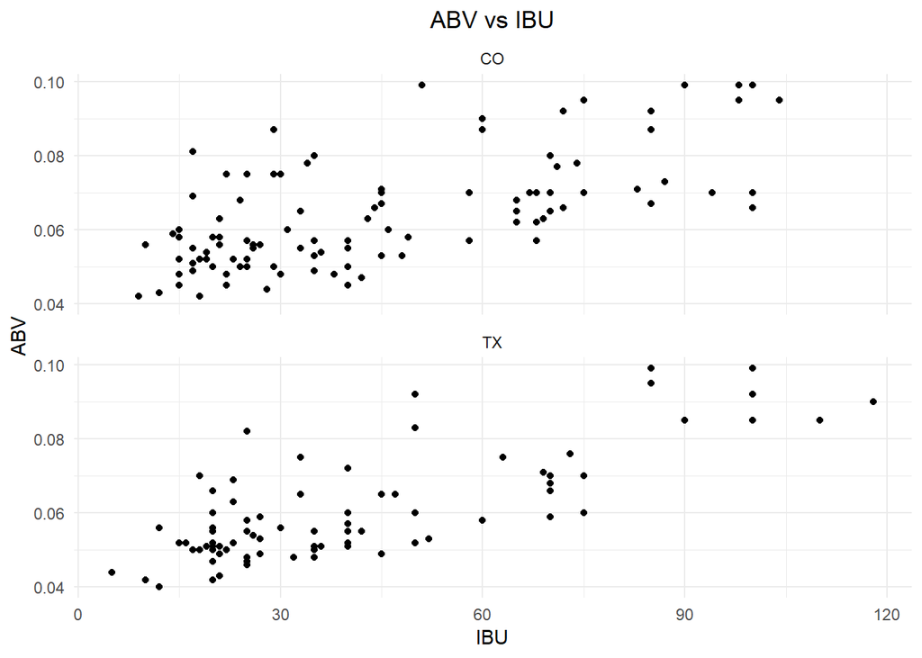

```r
#plot ABV vs. IBU for CO and TX
p <- ggplot(beerCOTX, aes(y=ABV, x=IBU)) + geom_point() + facet_wrap(~State, nrow=2) + theme_minimal()
p = p +  ggtitle(label="ABV vs IBU") + theme(plot.title=element_text(hjust=0.5)) +  theme(legend.position="right")
p
```

## Question C: Model the data

```r
beerTX <- beerCOTX %>% filter(State=="TX") %>% select(ABV, IBU, State)
beerCO <- beerCOTX %>% filter(State=="CO") %>% select(ABV, IBU, State)
plot(x=beerTX$IBU,y=beerTX$ABV, pch = 20, col = "red", xlab = "IBU", ylab="ABV", main = "IBU vs. ABV for TEXAS") #scatter plot of y versus x_1
fit = lm(ABV~IBU,data = beerTX) # fit the model to get Beta_hat_0 and Beta_hat_1
summary(fit) # view the parameter estimate table
```

```
##
## Call:
## lm(formula = ABV ~ IBU, data = beerTX)
##
## Residuals:
##       Min        1Q    Median        3Q       Max
## -0.014764 -0.005738 -0.001560  0.003182  0.028096
##
## Coefficients:
##              Estimate Std. Error t value Pr(>|t|)
## (Intercept) 4.347e-02  1.772e-03   24.54   <2e-16 ***
## IBU         4.172e-04  3.683e-05   11.33   <2e-16 ***
## ---
## Signif. codes:  0 '***' 0.001 '**' 0.01 '*' 0.05 '.' 0.1 ' ' 1
##
## Residual standard error: 0.009078 on 87 degrees of freedom
## Multiple R-squared:  0.596,  Adjusted R-squared:  0.5914
## F-statistic: 128.3 on 1 and 87 DF,  p-value: < 2.2e-16
```

```r
confint(fit)
```

```
##                   2.5 %       97.5 %
## (Intercept) 0.039952379 0.0469949413
## IBU         0.000344007 0.0004903987
```

```r
preds = predict(fit)
head(preds)
```

```
##          1          2          3          4          5          6
## 0.04555967 0.04555967 0.04764569 0.04848009 0.04848009 0.04973170
```

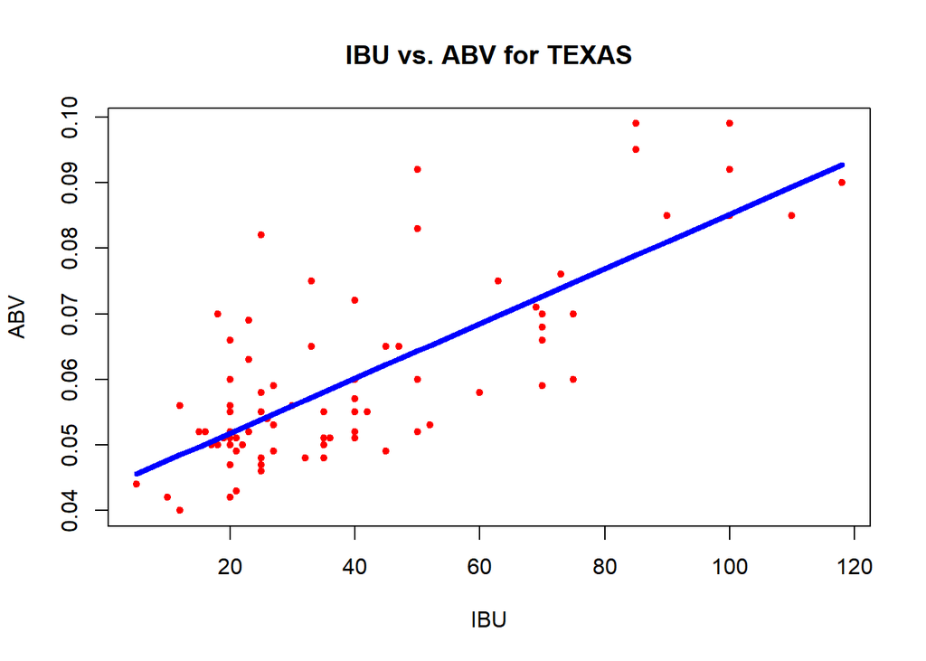

```r
lines(x=beerTX$IBU,y=preds,type = "l",lwd = 4, col="blue")
```

```r
plot(beerCO$IBU,beerCO$ABV, pch = 20, col = "red", xlab = "IBU", ylab="ABV", main = "IBU vs. ABV for COLORADO") #scatter plot of y versus x_1
fit = lm(ABV~IBU,data = beerCO) # fit the model to get Beta_hat_0 and Beta_hat_1
summary(fit) # view the parameter estimate table
```

```
##
## Call:
## lm(formula = ABV ~ IBU, data = beerCO)
##
## Residuals:
##       Min        1Q    Median        3Q       Max
## -0.018158 -0.007266 -0.003293  0.006453  0.032853
##
## Coefficients:
##              Estimate Std. Error t value Pr(>|t|)
## (Intercept) 4.740e-02  1.856e-03   25.54   <2e-16 ***
## IBU         3.676e-04  3.432e-05   10.71   <2e-16 ***
## ---
## Signif. codes:  0 '***' 0.001 '**' 0.01 '*' 0.05 '.' 0.1 ' ' 1
##
## Residual standard error: 0.01077 on 144 degrees of freedom
## Multiple R-squared:  0.4433, Adjusted R-squared:  0.4395
## F-statistic: 114.7 on 1 and 144 DF,  p-value: < 2.2e-16
```

```r
confint(fit)
```

```
##                   2.5 %       97.5 %
## (Intercept) 0.043732505 0.0510700022
## IBU         0.000299726 0.0004354124
```

```r
preds = predict(fit)
head(preds)
```

```
##          1          2          3          4          5          6
## 0.05070938 0.05107695 0.05181208 0.05254722 0.05254722 0.05291479
```

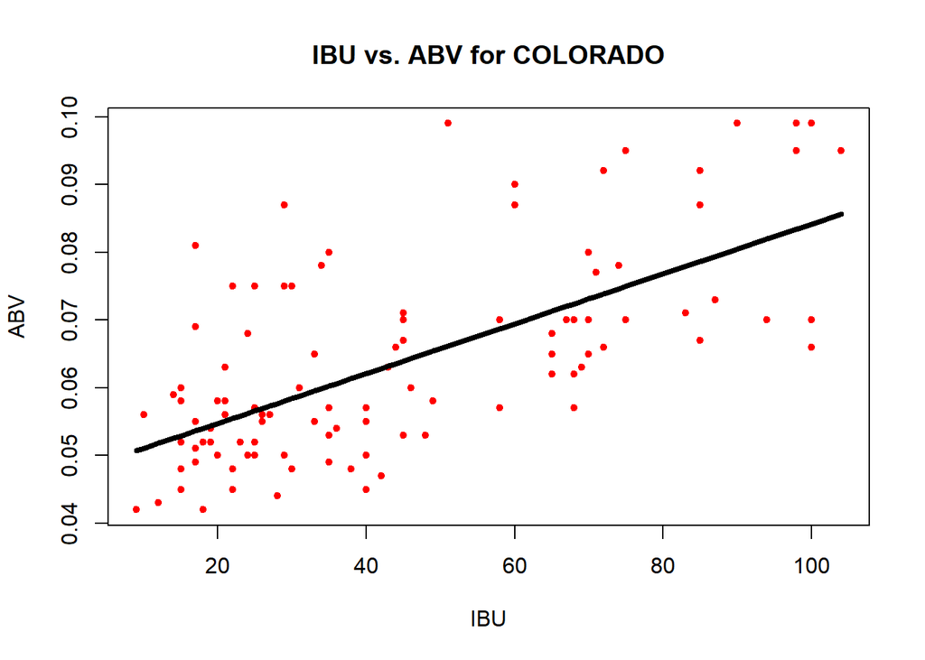

```r
lines(beerCO$IBU,preds,type = "l",lwd = 4, col="black")
```

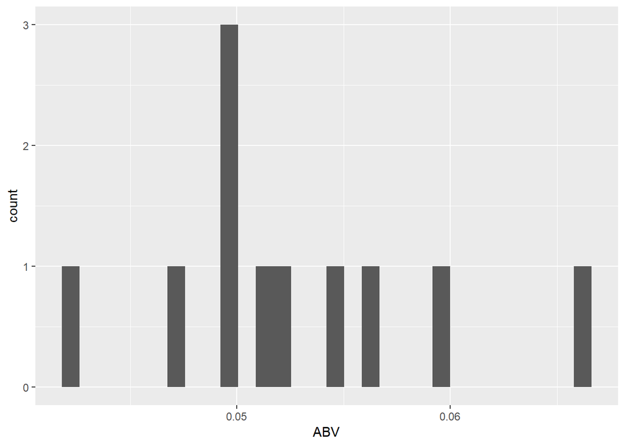

```r
# Address the assumptions of the regression model

#1. Look at distribution of ys for a cross section of xs (conditiona on the xs).
beerTX %>% filter(IBU >19 & IBU < 21) %>% ggplot(aes(x = ABV)) + geom_histogram() #looking OK as a normal distribution
```

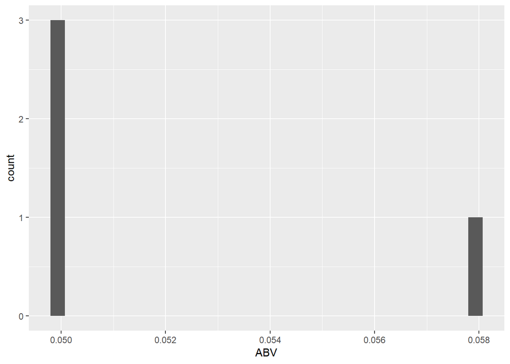

```r
beerCO %>% filter(IBU >19 & IBU < 21) %>% ggplot(aes(x = ABV)) + geom_histogram() #not looking good as a normal distribution
```

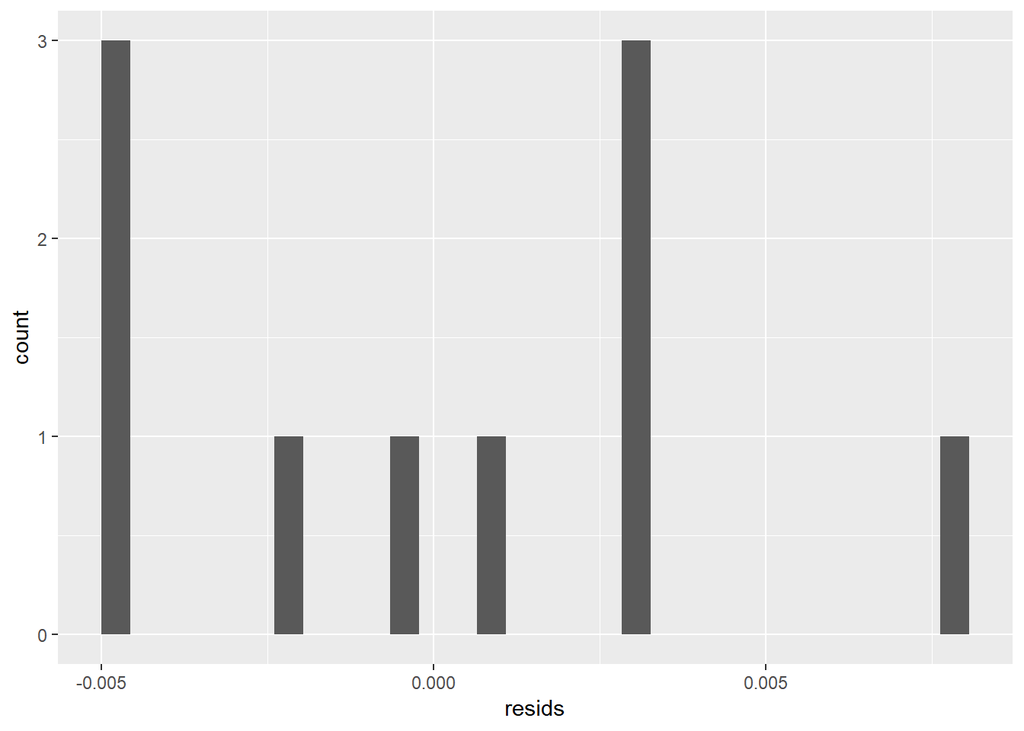

```r
#2. Check if these normal distributions have equal standard deviations.
#Look at the residuals for a cross section of the xs (conditional on the xs).
beerCO$resids = fit$residuals
beerCO %>% filter(IBU >18 & IBU < 22) %>% ggplot(aes(x = resids)) + geom_histogram() #looking not too bad
```

```r
#standard deviation of residuals.
sd((beerCO %>% filter(IBU >18 & IBU < 22))$resids)
```

```
## [1] 0.004262784
```

```r
sd((beerCO %>% filter(IBU >28 & IBU < 32))$resids)
```

```
## [1] 0.01478001
```

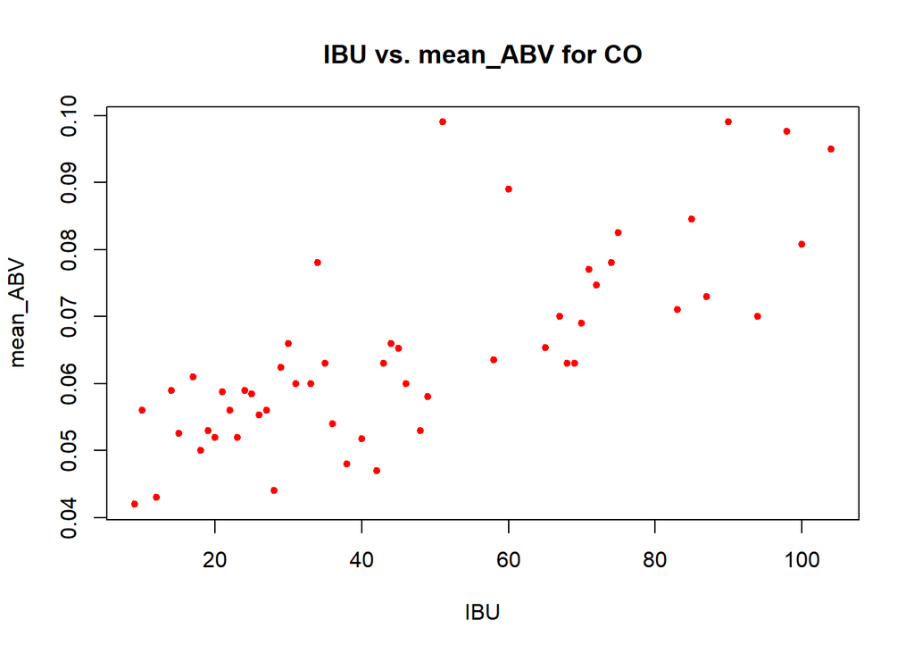

```r
#due to the limited data points, the SD of residuals at different points are not the same.

#3. The means of these normal distributions have a linear relationship with IBU.
mean_value <- beerCO %>% group_by(IBU) %>% dplyr::summarise(mean_ABV=mean(ABV))
plot(x=mean_value$IBU, y=mean_value$mean_ABV, pch = 20, col = "red", xlab = "IBU", ylab="mean_ABV", main = "IBU vs. mean_ABV for CO")
```

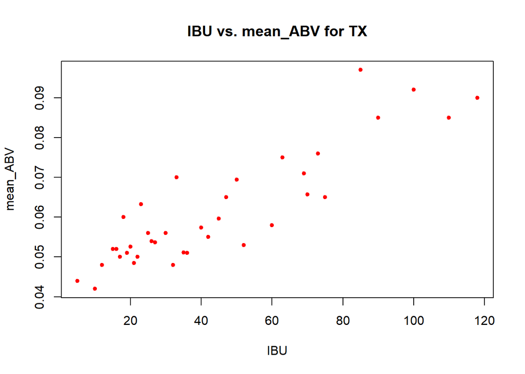

```r
mean_value <- beerTX %>% group_by(IBU) %>% dplyr::summarise(mean_ABV=mean(ABV))
plot(x=mean_value$IBU, y=mean_value$mean_ABV, pch = 20, col = "red", xlab = "IBU", ylab="mean_ABV", main = "IBU vs. mean_ABV for TX")
```

```r
#both plots look pretty good in terms of the linearity between mean ABV on each IBU.

#4. Independence (you may assume this one to be true without defense.)
```

```r
#to answer this question more efficiently, we have to use ggfortigfy package to get diagonosis plot.

library(ggfortify)
sapply(beerTX, function(x) sum(is.na(x)))
```

```
##   ABV   IBU State
##     0     0     0
```

```r
nrow(beerTX)
```

```
## [1] 89
```

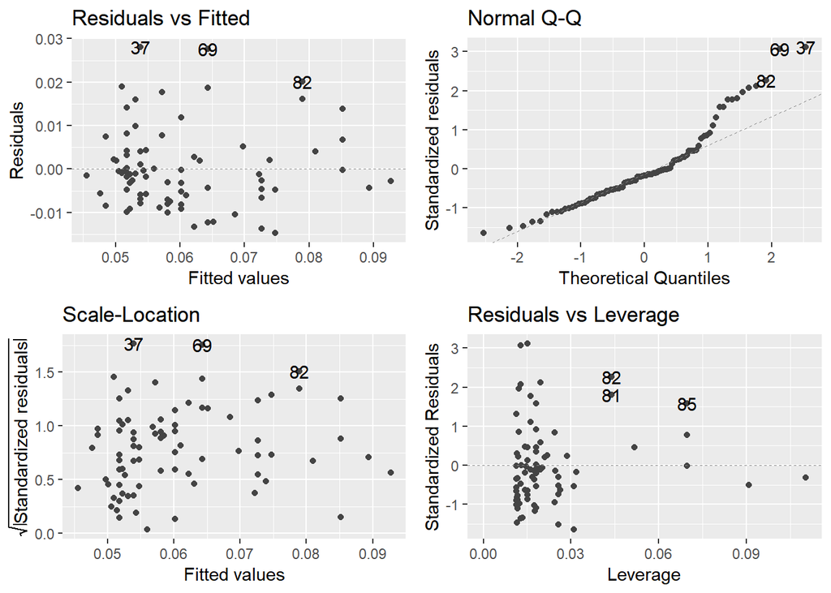

```r
fit = lm(ABV~IBU,data = beerTX)
#head(fit)
autoplot(fit, smooth.colour = NA)
```

## For TX dataset: by examing the diagnostic plots, it appears that normality assumption is not perfectly met based on the normal Q-Q plot. The equal variance is roughly met based on the square-root of standardized residual vs. fitted values plot. The residuals vs leverage plot showed some influential data points (number-labled). We assume that the independence assumption is met.

```r
sapply(beerCO, function(x) sum(is.na(x)))
```

```
##    ABV    IBU  State resids
##      0      0      0      0
```

```r
fit = lm(ABV~IBU,data = beerCO)
nrow(beerCO)
```

```
## [1] 146
```

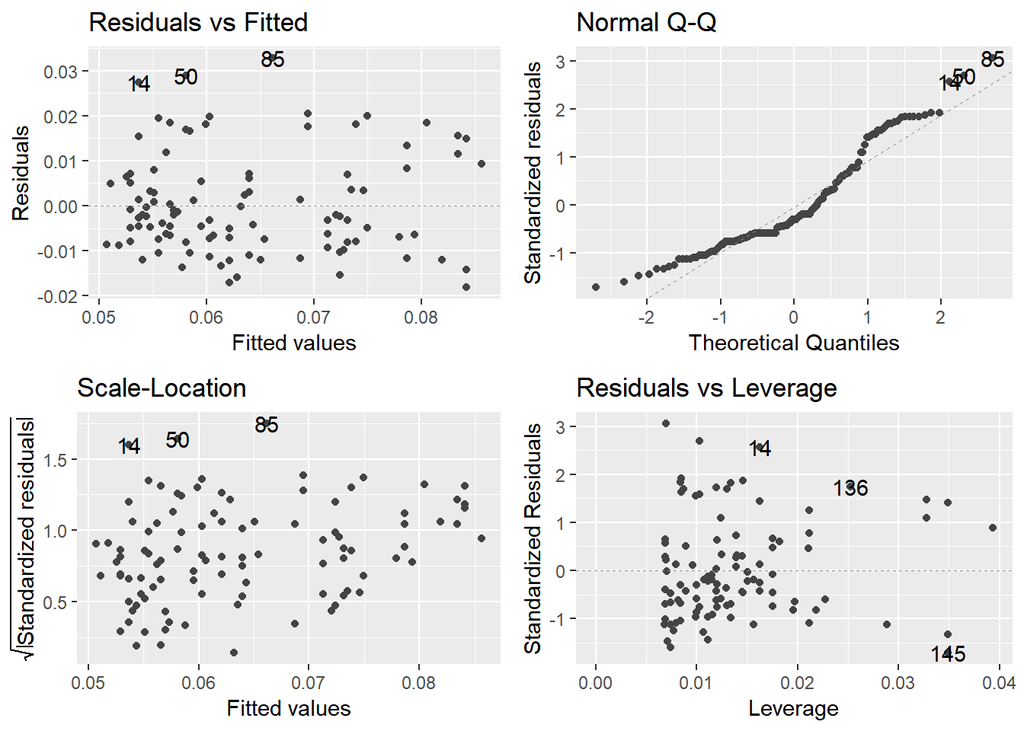

```r
autoplot(fit, smooth.colour = NA)
```

## For CO dataset: by examing the diagnostic plots, it appears that normality is not ideally met (normal Q-Q plot) and equal variance is not met. There is a funnel-like shape in the plot of square-root of |standarized residual| vs. fitted values. The residuals vs leverage plot showed a few influential data points, labeled in numbers, but overall, it was acceptable. We assume that the independence assumption is met.

# Question D. Gain inference from the model

```r
#get parameter table and 95% CI
fit = lm(ABV~IBU,data = beerTX) # fit the model to get Beta_hat_0 and Beta_hat_1
summary(fit) # view the parameter estimate table
```

```
##
## Call:
## lm(formula = ABV ~ IBU, data = beerTX)
##
## Residuals:
##       Min        1Q    Median        3Q       Max
## -0.014764 -0.005738 -0.001560  0.003182  0.028096
##
## Coefficients:
##              Estimate Std. Error t value Pr(>|t|)
## (Intercept) 4.347e-02  1.772e-03   24.54   <2e-16 ***
## IBU         4.172e-04  3.683e-05   11.33   <2e-16 ***
## ---
## Signif. codes:  0 '***' 0.001 '**' 0.01 '*' 0.05 '.' 0.1 ' ' 1
##
## Residual standard error: 0.009078 on 87 degrees of freedom
## Multiple R-squared:  0.596,  Adjusted R-squared:  0.5914
## F-statistic: 128.3 on 1 and 87 DF,  p-value: < 2.2e-16
```

```r
confint(fit)
```

```
##                   2.5 %       97.5 %
## (Intercept) 0.039952379 0.0469949413
## IBU         0.000344007 0.0004903987
```

## For TX dataset, the obtained regression equation is: mean_ABV(ABV|IBU) = 0.04347 + 0.0004172*IBU. Interpretation of the slope: for one unit incrase in IBU, there is 0.0004172 unit increase on ABV. The 95% confidence interval for the sclope (TX) is: [0.000344, 0.00049], The 95% confidence interval defines a range of values that you can be 95% certain contains the population mean of the slope.

## The interpretation of 95% CI: If thousands of samples of n items are drawn from a population using simple random sampling and a confidence interval is calculated for each sample, the proportion of those intervals that will include the true population slope is 95%.

```r
fit = lm(ABV~IBU,data = beerCO) # fit the model to get Beta_hat_0 and Beta_hat_1
summary(fit) # view the parameter estimate table
```

```
##
## Call:
## lm(formula = ABV ~ IBU, data = beerCO)
##
## Residuals:
##       Min        1Q    Median        3Q       Max
## -0.018158 -0.007266 -0.003293  0.006453  0.032853
##
## Coefficients:
##              Estimate Std. Error t value Pr(>|t|)
## (Intercept) 4.740e-02  1.856e-03   25.54   <2e-16 ***
## IBU         3.676e-04  3.432e-05   10.71   <2e-16 ***
## ---
## Signif. codes:  0 '***' 0.001 '**' 0.01 '*' 0.05 '.' 0.1 ' ' 1
##
## Residual standard error: 0.01077 on 144 degrees of freedom
## Multiple R-squared:  0.4433, Adjusted R-squared:  0.4395
## F-statistic: 114.7 on 1 and 144 DF,  p-value: < 2.2e-16
```

```r
confint(fit)
```

```
##                   2.5 %       97.5 %
## (Intercept) 0.043732505 0.0510700022
## IBU         0.000299726 0.0004354124
```

## For CO dataset, the obtained regression equation is: mean_ABV(ABV|IBU) = 0.0474 + 0.0003676*IBU. Interpretation of the slope: for one unit incrase in IBU, there is 0.0003676 unit increase on ABV. The 95% confidence interval for the sclope (CO) is: [0.0003, 0.000435], The 95% confidence interval defines a range of values that you can be 95% certain contains the population mean of the slope.

## There is no evience to suggest that the relationship between ABV and IBU is significantly different between Texas and Colorado beers. This is becuase the 95% confidence interval of the slope in Texas ABV vs. IBU linear fitting is greatly overalpping with 95% CI of the slope in Colorado ABV vs. IBU fitting. The 95% CI for the former is [0.000344, 0.000490], while for the latter is [0.0003, 0.000435].

# Question E. Compare two competing models: External Cross Validation

```r
#11.Using the beerCOTX dataframe, add a column to the data that is the square of the IBU column, IBU2
beerCOTX$IBU2 <- (beerCOTX$IBU)^2
head(beerCOTX)
```

```
## # A tibble: 6 x 11
## # Groups:   State [2]
##   Brew_ID Name_beer Beer_ID   ABV   IBU Style Ounces Name_brew City  State
##     <int> <fct>       <int> <dbl> <int> <fct>  <dbl> <fct>     <fct> <fct>
## 1      67 Yo Soy U~    2520 0.044     5 Berl~     12 Freetail~ San ~ TX
## 2     129 18th Ann~    2370 0.044     5 Gose      12 Real Ale~ Blan~ TX
## 3     392 Agave Wh~    1522 0.042     9 Amer~     12 Breckenr~ Denv~ CO
## 4      38 White Ra~     108 0.056    10 Witb~     12 Avery Br~ Boul~ CO
## 5      67 Rye Wit      2522 0.042    10 Witb~     12 Freetail~ San ~ TX
## 6     188 Lobo Lito    2238 0.04     12 Ligh~     12 Pedernal~ Fred~ TX
## # ... with 1 more variable: IBU2 <dbl>
```

```r
#12. For each state, create a training and test set from the data (60%/40% split respectively).
#Print a summary of each new data frame. there should be four: TrainingCO, TestCO, TrainingTX, TestTX

#Divide into training and test set with 60% for training and 40% for test
beerTX <- beerCOTX %>% filter(State=="TX")
beerCO <- beerCOTX %>% filter(State=="CO")
samplesize_TX=nrow(beerTX)
samplesize_TX
```

```
## [1] 89
```

```r
samplesize_CO=nrow(beerCO)
samplesize_CO
```

```
## [1] 146
```

```r
train_perc = 0.60
train_indices_TX = sample(seq(1,samplesize_TX,length = samplesize_TX),round(train_perc*samplesize_TX))
train_indices_CO = sample(seq(1,samplesize_CO,length = samplesize_CO),round(train_perc*samplesize_CO))

TrainingTX = beerTX[train_indices_TX,]
summary(TrainingTX)
```

```
##     Brew_ID                    Name_beer     Beer_ID          ABV
##  Min.   : 30   Bombshell Blonde     : 2   Min.   :  44   Min.   :0.04200
##  1st Qu.:119   Pine Belt Pale Ale   : 2   1st Qu.:1086   1st Qu.:0.05000
##  Median :128   1836                 : 1   Median :2041   Median :0.05600
##  Mean   :153   18th Anniversary Gose: 1   Mean   :1713   Mean   :0.06109
##  3rd Qu.:188   Alteration           : 1   3rd Qu.:2247   3rd Qu.:0.06900
##  Max.   :427   Barn Burner Saison   : 1   Max.   :2600   Max.   :0.09900
##                (Other)              :45
##       IBU                                    Style        Ounces
##  Min.   :  5.00   American Blonde Ale           : 7   Min.   :12.00
##  1st Qu.: 20.00   American Amber / Red Ale      : 4   1st Qu.:12.00
##  Median : 27.00   American Double / Imperial IPA: 3   Median :12.00
##  Mean   : 36.72   American IPA                  : 3   Mean   :12.75
##  3rd Qu.: 47.00   American Pale Ale (APA)       : 3   3rd Qu.:12.00
##  Max.   :100.00   (Other)                       :32   Max.   :16.00
##                   NA's                          : 1
##                          Name_brew               City        State
##  Southern Star Brewing Company:10   Conroe         :10   TX     :53
##  Karbach Brewing Company      : 6   Austin         : 7   AK     : 0
##  Freetail Brewing Company     : 5   Houston        : 7   AL     : 0
##  Real Ale Brewing Company     : 4   San Antonio    : 6   AR     : 0
##  New Republic Brewing Company : 3   Blanco         : 4   AZ     : 0
##  Cedar Creek Brewery          : 2   College Station: 3   CA     : 0
##  (Other)                      :23   (Other)        :16   (Other): 0
##       IBU2
##  Min.   :   25
##  1st Qu.:  400
##  Median :  729
##  Mean   : 1859
##  3rd Qu.: 2209
##  Max.   :10000
##
```

```r
TestTX = beerTX[-train_indices_TX,]
summary(TestTX)
```

```
##     Brew_ID                          Name_beer     Beer_ID
##  Min.   : 30.0   Bat Outta Helles         : 1   Min.   : 465
##  1st Qu.:126.0   Battle LIne              : 1   1st Qu.:1300
##  Median :135.0   Block Party Robust Porter: 1   Median :2045
##  Mean   :169.5   Broken Bridge            : 1   Mean   :1764
##  3rd Qu.:215.0   Cow Creek                : 1   3rd Qu.:2128
##  Max.   :427.0   Dankosaurus              : 1   Max.   :2588
##                  (Other)                  :30
##       ABV               IBU                                    Style
##  Min.   :0.04000   Min.   : 12.00   American IPA                  : 6
##  1st Qu.:0.05075   1st Qu.: 21.00   American Pale Ale (APA)       : 6
##  Median :0.05500   Median : 35.50   American Double / Imperial IPA: 5
##  Mean   :0.05919   Mean   : 45.81   Saison / Farmhouse Ale        : 3
##  3rd Qu.:0.06425   3rd Qu.: 70.00   American Amber / Red Lager    : 2
##  Max.   :0.09500   Max.   :118.00   American Blonde Ale           : 2
##                                     (Other)                       :12
##      Ounces                              Name_brew              City
##  Min.   :12.00   Karbach Brewing Company      : 4   Austin        : 6
##  1st Qu.:12.00   Cedar Creek Brewery          : 3   Houston       : 6
##  Median :12.00   Deep Ellum Brewing Company   : 3   Dallas        : 5
##  Mean   :12.89   Grapevine Craft Brewery      : 3   Blanco        : 3
##  3rd Qu.:12.00   Real Ale Brewing Company     : 3   Farmers Branch: 3
##  Max.   :16.00   Buffalo Bayou Brewing Company: 2   Seven Points  : 3
##                  (Other)                      :18   (Other)       :10
##      State         IBU2
##  TX     :36   Min.   :  144
##  AK     : 0   1st Qu.:  441
##  AL     : 0   Median : 1260
##  AR     : 0   Mean   : 2985
##  AZ     : 0   3rd Qu.: 4900
##  CA     : 0   Max.   :13924
##  (Other): 0
```

```r
TrainingCO = beerCO[train_indices_CO,]
summary(TrainingCO)
```

```
##     Brew_ID                           Name_beer     Beer_ID
##  Min.   : 38.0   Dale's Pale Ale           : 3   Min.   :  67.0
##  1st Qu.:111.0   1554 Black Lager          : 1   1st Qu.: 593.2
##  Median :167.0   5:00 O'Clock Afternoon Ale: 1   Median : 904.5
##  Mean   :249.6   American Red Saison       : 1   Mean   :1043.8
##  3rd Qu.:422.0   Apricot Blonde            : 1   3rd Qu.:1452.5
##  Max.   :524.0   Avery India Pale Ale      : 1   Max.   :2538.0
##                  (Other)                   :80
##       ABV               IBU                                    Style
##  Min.   :0.04200   Min.   : 10.00   American IPA                  :14
##  1st Qu.:0.05300   1st Qu.: 23.00   American Pale Ale (APA)       :14
##  Median :0.06500   Median : 40.00   American Double / Imperial IPA: 8
##  Mean   :0.06475   Mean   : 46.92   American Amber / Red Ale      : 5
##  3rd Qu.:0.07000   3rd Qu.: 68.00   American Pale Lager           : 4
##  Max.   :0.09900   Max.   :104.00   American Amber / Red Lager    : 3
##                                     (Other)                       :40
##      Ounces                           Name_brew            City
##  Min.   :12.0   Oskar Blues Brewery        :15   Boulder     :16
##  1st Qu.:12.0   New Belgium Brewing Company: 7   Denver      :10
##  Median :12.0   Renegade Brewing Company   : 6   Fort Collins:10
##  Mean   :13.2   Pug Ryan's Brewery         : 5   Longmont    :10
##  3rd Qu.:16.0   Upslope Brewing Company    : 5   Durango     : 6
##  Max.   :19.2   Bonfire Brewing Company    : 4   Dillon      : 5
##                 (Other)                    :46   (Other)     :31
##      State         IBU2
##  CO     :88   Min.   :  100
##  AK     : 0   1st Qu.:  529
##  AL     : 0   Median : 1600
##  AR     : 0   Mean   : 2901
##  AZ     : 0   3rd Qu.: 4624
##  CA     : 0   Max.   :10816
##  (Other): 0
```

```r
TestCO = beerCO[-train_indices_CO,]
summary(TestCO)
```

```
##     Brew_ID                           Name_beer     Beer_ID
##  Min.   :  7.0   Fat Tire Amber Ale        : 2   Min.   :   1.0
##  1st Qu.:108.0   Firestarter India Pale Ale: 2   1st Qu.: 591.8
##  Median :167.0   Agave Wheat               : 1   Median : 807.0
##  Mean   :244.1   American India Red Ale    : 1   Mean   :1133.3
##  3rd Qu.:402.5   American Red Porter       : 1   3rd Qu.:1848.5
##  Max.   :521.0   AprÃ¨ Shred               : 1   Max.   :2644.0
##                  (Other)                   :50
##       ABV               IBU                                    Style
##  Min.   :0.04200   Min.   :  9.00   American Pale Ale (APA)       :11
##  1st Qu.:0.05300   1st Qu.: 25.75   American IPA                  : 9
##  Median :0.06500   Median : 43.00   American Amber / Red Ale      : 5
##  Mean   :0.06497   Mean   : 48.21   Russian Imperial Stout        : 4
##  3rd Qu.:0.07100   3rd Qu.: 65.00   American Double / Imperial IPA: 3
##  Max.   :0.09900   Max.   :100.00   Czech Pilsener                : 3
##                                     (Other)                       :23
##      Ounces                            Name_brew            City
##  Min.   :12.00   Oskar Blues Brewery        :17   Boulder     :10
##  1st Qu.:12.00   New Belgium Brewing Company: 5   Longmont    :10
##  Median :12.00   Bonfire Brewing Company    : 4   Denver      : 7
##  Mean   :13.06   Black Shirt Brewing Company: 3   Fort Collins: 7
##  3rd Qu.:12.00   Breckenridge Brewery       : 3   Lyons       : 7
##  Max.   :19.20   Upslope Brewing Company    : 3   Eagle       : 4
##                  (Other)                    :23   (Other)     :13
##      State         IBU2
##  CO     :58   Min.   :   81.0
##  AK     : 0   1st Qu.:  664.8
##  AL     : 0   Median : 1850.0
##  AR     : 0   Mean   : 2960.2
##  AZ     : 0   3rd Qu.: 4225.0
##  CA     : 0   Max.   :10000.0
##  (Other): 0
```

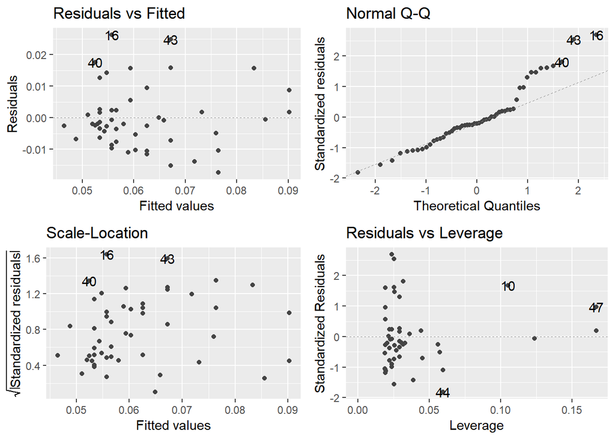

```r
#13.  Brewmeisters are curious if the relationship between ABV and IBU is purely linear or quadratic.

#result for TX
ASEholderTrain1_TX = c()
ASEholderTest1_TX = c()
ASEholderTrain2_TX = c()
ASEholderTest2_TX = c()

fitTrain1 = lm(ABV~IBU, data = TrainingTX)
autoplot(fitTrain1, smooth.colour = NA)
```

```r
summary(fitTrain1)
```

```
##
## Call:
## lm(formula = ABV ~ IBU, data = TrainingTX)
##
## Residuals:
##       Min        1Q    Median        3Q       Max
## -0.017403 -0.006405 -0.002005  0.002375  0.026295
##
## Coefficients:
##             Estimate Std. Error t value Pr(>|t|)
## (Intercept) 0.044206   0.002587  17.090  < 2e-16 ***
## IBU         0.000460   0.000060   7.667 4.84e-10 ***
## ---
## Signif. codes:  0 '***' 0.001 '**' 0.01 '*' 0.05 '.' 0.1 ' ' 1
##
## Residual standard error: 0.009871 on 51 degrees of freedom
## Multiple R-squared:  0.5354, Adjusted R-squared:  0.5263
## F-statistic: 58.78 on 1 and 51 DF,  p-value: 4.84e-10
```

```r
# These are the predictions of the model on the data that were used to fit the model.
predsTrain1 = predict(fitTrain1)
# These are the predictions of the model on the data that were NOT used to fit the model.
# This is a better measure of how the model will perform in real life
predsTest1 = predict(fitTrain1, newdata = TestTX)
TestTX$preds1 <- predsTest1
head(TestTX)
```

```
## # A tibble: 6 x 12
## # Groups:   State [1]
##   Brew_ID Name_beer Beer_ID   ABV   IBU Style Ounces Name_brew City  State
##     <int> <fct>       <int> <dbl> <int> <fct>  <dbl> <fct>     <fct> <fct>
## 1     188 Lobo Lito    2238 0.04     12 Ligh~     12 Pedernal~ Fred~ TX
## 2     216 Broken B~    2117 0.056    12 Dunk~     12 Texian B~ Rich~ TX
## 3     126 Weisse V~    2374 0.052    16 Hefe~     12 Karbach ~ Hous~ TX
## 4      67 Bat Outt~    2524 0.042    20 Muni~     12 Freetail~ San ~ TX
## 5     162 River Ho~    2308 0.05     20 Sais~     16 Martin H~ Fort~ TX
## 6     215 Summer's~    2124 0.06     20 Witb~     12 Buffalo ~ Hous~ TX
## # ... with 2 more variables: IBU2 <dbl>, preds1 <dbl>
```

```r
# Calculation of the ASE for the Test set for one variable
ASEholderTest1_TX = sum((TestTX$preds1 - TestTX$ABV)^2)/(length(TestTX$ABV))
ASEholderTest1_TX
```

```
## [1] 7.914531e-05
```

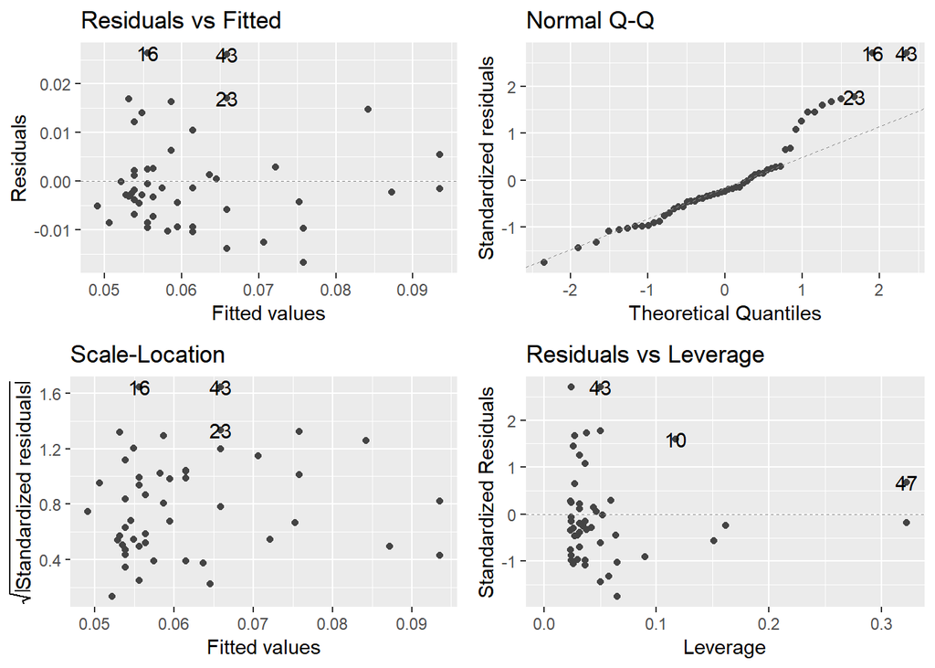

```r
fitTrain2 = lm(ABV~IBU+IBU2, data = TrainingTX)
autoplot(fitTrain2, smooth.colour = NA)
```

```r
summary(fitTrain2)
```

```
##
## Call:
## lm(formula = ABV ~ IBU + IBU2, data = TrainingTX)
##
## Residuals:
##       Min        1Q    Median        3Q       Max
## -0.016796 -0.005876 -0.002232  0.002657  0.026391
##
## Coefficients:
##              Estimate Std. Error t value Pr(>|t|)
## (Intercept) 4.771e-02  4.871e-03   9.794 3.22e-13 ***
## IBU         2.685e-04  2.331e-04   1.152    0.255
## IBU2        1.896e-06  2.230e-06   0.850    0.399
## ---
## Signif. codes:  0 '***' 0.001 '**' 0.01 '*' 0.05 '.' 0.1 ' ' 1
##
## Residual standard error: 0.009898 on 50 degrees of freedom
## Multiple R-squared:  0.542,  Adjusted R-squared:  0.5237
## F-statistic: 29.59 on 2 and 50 DF,  p-value: 3.316e-09
```

```r
# These are the predictions of the model on the data that were used to fit the model.
predsTrain2 = predict(fitTrain2)
# These are the predictions of the model on the data that were NOT used to fit the model.
# This is a better measure of how the model will perform in real life
predsTest2 = predict(fitTrain2, newdata = TestTX)
TestTX$preds2 <- predsTest2
head(TestTX)
```

```
## # A tibble: 6 x 13
## # Groups:   State [1]
##   Brew_ID Name_beer Beer_ID   ABV   IBU Style Ounces Name_brew City  State
##     <int> <fct>       <int> <dbl> <int> <fct>  <dbl> <fct>     <fct> <fct>
## 1     188 Lobo Lito    2238 0.04     12 Ligh~     12 Pedernal~ Fred~ TX
## 2     216 Broken B~    2117 0.056    12 Dunk~     12 Texian B~ Rich~ TX
## 3     126 Weisse V~    2374 0.052    16 Hefe~     12 Karbach ~ Hous~ TX
## 4      67 Bat Outt~    2524 0.042    20 Muni~     12 Freetail~ San ~ TX
## 5     162 River Ho~    2308 0.05     20 Sais~     16 Martin H~ Fort~ TX
## 6     215 Summer's~    2124 0.06     20 Witb~     12 Buffalo ~ Hous~ TX
## # ... with 3 more variables: IBU2 <dbl>, preds1 <dbl>, preds2 <dbl>
```

```r
# Calculation of the ASE for the Test set for two variables IBU and IBU2
ASEholderTest2_TX = sum((TestTX$preds2 - TestTX$ABV)^2)/(length(TestTX$ABV))
ASEholderTest2_TX
```

```
## [1] 8.576461e-05
```

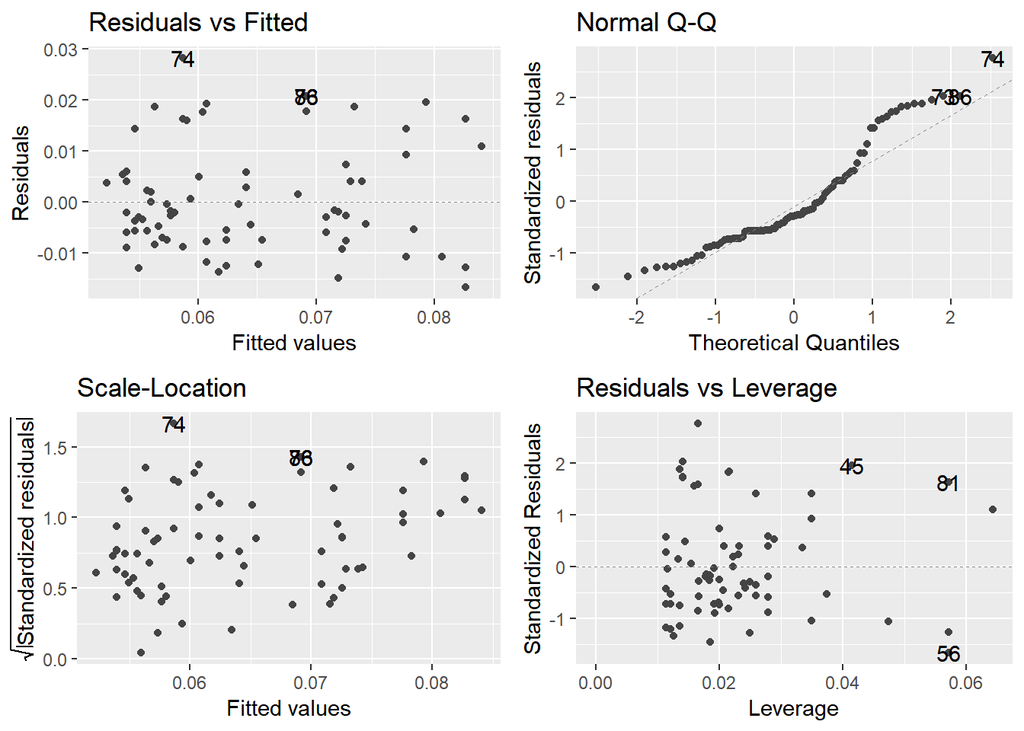

```r
#result for CO
ASEholderTrain1_CO = c()
ASEholderTest1_CO = c()
ASEholderTrain2_CO = c()
ASEholderTest2_CO = c()

fitTrain1 = lm(ABV~IBU, data = TrainingCO)
autoplot(fitTrain1, smooth.colour = NA)
```

```r
summary(fitTrain1)
```

```
##
## Call:
## lm(formula = ABV ~ IBU, data = TrainingCO)
##
## Residuals:
##       Min        1Q    Median        3Q       Max
## -0.016703 -0.007082 -0.002917  0.005065  0.028311
##
## Coefficients:
##              Estimate Std. Error t value Pr(>|t|)
## (Intercept) 4.888e-02  2.234e-03  21.878  < 2e-16 ***
## IBU         3.382e-04  4.148e-05   8.154 2.59e-12 ***
## ---
## Signif. codes:  0 '***' 0.001 '**' 0.01 '*' 0.05 '.' 0.1 ' ' 1
##
## Residual standard error: 0.01029 on 86 degrees of freedom
## Multiple R-squared:  0.436,  Adjusted R-squared:  0.4294
## F-statistic: 66.48 on 1 and 86 DF,  p-value: 2.586e-12
```

```r
# These are the predictions of the model on the data that were used to fit the model.
predsTrain1 = predict(fitTrain1)
# These are the predictions of the model on the data that were NOT used to fit the model.
# This is a better measure of how the model will perform in real life
predsTest1 = predict(fitTrain1, newdata = TestCO)
TestCO$preds1 <- predsTest1
head(TestCO)
```

```
## # A tibble: 6 x 12
## # Groups:   State [1]
##   Brew_ID Name_beer Beer_ID   ABV   IBU Style Ounces Name_brew City  State
##     <int> <fct>       <int> <dbl> <int> <fct>  <dbl> <fct>     <fct> <fct>
## 1     392 Agave Wh~    1522 0.042     9 Amer~     12 Breckenr~ Denv~ CO
## 2     497 Dry Dock~     872 0.043    12 Hefe~     12 Dry Dock~ Auro~ CO
## 3     136 Morning ~     130 0.059    14 Amer~     12 Pug Ryan~ Dill~ CO
## 4      38 Ellieâ~     106 0.055    17 Amer~     12 Avery Br~ Boul~ CO
## 5     221 AprÃ¨ Sh~    2104 0.081    17 Amer~     16 Big Choi~ Broo~ CO
## 6      83 Fat Tire~    1586 0.052    18 Amer~     12 New Belg~ Fort~ CO
## # ... with 2 more variables: IBU2 <dbl>, preds1 <dbl>
```

```r
# Calculation of the ASE for the Test set for one variable
ASEholderTest1_CO = sum((TestCO$preds1 - TestCO$ABV)^2)/(length(TestCO$ABV))
ASEholderTest1_CO
```

```
## [1] 0.0001325746
```

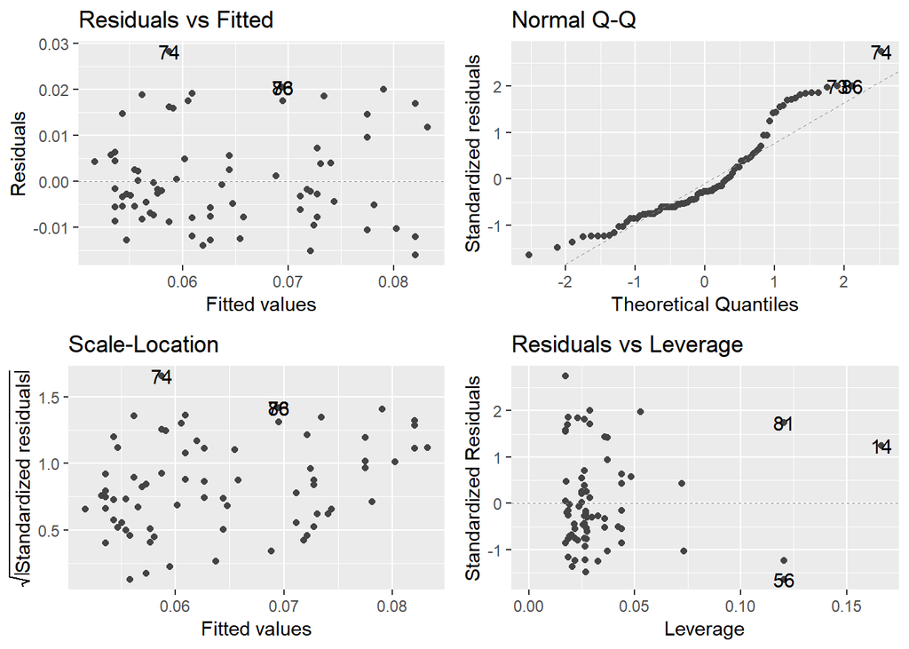

```r
fitTrain2 = lm(ABV~IBU+IBU2, data = TrainingCO)
autoplot(fitTrain2, smooth.colour = NA)
```

```r
summary(fitTrain2)
```

```
##
## Call:
## lm(formula = ABV ~ IBU + IBU2, data = TrainingCO)
##
## Residuals:
##       Min        1Q    Median        3Q       Max
## -0.016023 -0.007034 -0.002752  0.004999  0.028240
##
## Coefficients:
##               Estimate Std. Error t value Pr(>|t|)
## (Intercept)  4.789e-02  4.390e-03  10.909   <2e-16 ***
## IBU          3.883e-04  1.961e-04   1.980   0.0509 .
## IBU2        -4.703e-07  1.799e-06  -0.261   0.7945
## ---
## Signif. codes:  0 '***' 0.001 '**' 0.01 '*' 0.05 '.' 0.1 ' ' 1
##
## Residual standard error: 0.01035 on 85 degrees of freedom
## Multiple R-squared:  0.4364, Adjusted R-squared:  0.4232
## F-statistic: 32.91 on 2 and 85 DF,  p-value: 2.598e-11
```

```r
# These are the predictions of the model on the data that were used to fit the model.
predsTrain2 = predict(fitTrain2)
# These are the predictions of the model on the data that were NOT used to fit the model.
# This is a better measure of how the model will perform in real life
predsTest2 = predict(fitTrain2, newdata = TestCO)
TestCO$preds2 <- predsTest2
head(TestCO)
```

```
## # A tibble: 6 x 13
## # Groups:   State [1]
##   Brew_ID Name_beer Beer_ID   ABV   IBU Style Ounces Name_brew City  State
##     <int> <fct>       <int> <dbl> <int> <fct>  <dbl> <fct>     <fct> <fct>
## 1     392 Agave Wh~    1522 0.042     9 Amer~     12 Breckenr~ Denv~ CO
## 2     497 Dry Dock~     872 0.043    12 Hefe~     12 Dry Dock~ Auro~ CO
## 3     136 Morning ~     130 0.059    14 Amer~     12 Pug Ryan~ Dill~ CO
## 4      38 Ellieâ~     106 0.055    17 Amer~     12 Avery Br~ Boul~ CO
## 5     221 AprÃ¨ Sh~    2104 0.081    17 Amer~     16 Big Choi~ Broo~ CO
## 6      83 Fat Tire~    1586 0.052    18 Amer~     12 New Belg~ Fort~ CO
## # ... with 3 more variables: IBU2 <dbl>, preds1 <dbl>, preds2 <dbl>
```

```r
# Calculation of the ASE for the Test set for two variables
ASEholderTest2_CO = sum((TestCO$preds2 - TestCO$ABV)^2)/(length(TestCO$ABV))
ASEholderTest2_CO
```

```
## [1] 0.0001348623
```

# BONUS: Is there another method that you know of that will provide inference as to the significance of the squared IBU term?

```r
#Please describe your thoughts and provide relevant statistics.  Does this inference agree with the result of your cross validation?

#just check if the p-value of the regression coefficients of IBU and IBU2 are significant using the whole dataset (for both TX and CO)
fit1 = lm(ABV~IBU, data = beerTX)
#autoplot(fitTrain1, smooth.colour = NA)
summary(fit1)
```

```
##
## Call:
## lm(formula = ABV ~ IBU, data = beerTX)
##
## Residuals:
##       Min        1Q    Median        3Q       Max
## -0.014764 -0.005738 -0.001560  0.003182  0.028096
##
## Coefficients:
##              Estimate Std. Error t value Pr(>|t|)
## (Intercept) 4.347e-02  1.772e-03   24.54   <2e-16 ***
## IBU         4.172e-04  3.683e-05   11.33   <2e-16 ***
## ---
## Signif. codes:  0 '***' 0.001 '**' 0.01 '*' 0.05 '.' 0.1 ' ' 1
##
## Residual standard error: 0.009078 on 87 degrees of freedom
## Multiple R-squared:  0.596,  Adjusted R-squared:  0.5914
## F-statistic: 128.3 on 1 and 87 DF,  p-value: < 2.2e-16
```

```r
fit12 = lm(ABV~IBU+IBU2, data = beerTX)
#autoplot(fitTrain1, smooth.colour = NA)
summary(fit12)
```

```
##
## Call:
## lm(formula = ABV ~ IBU + IBU2, data = beerTX)
##
## Residuals:
##       Min        1Q    Median        3Q       Max
## -0.014077 -0.006117 -0.001798  0.003708  0.028725
##
## Coefficients:
##              Estimate Std. Error t value Pr(>|t|)
## (Intercept) 4.611e-02  3.332e-03  13.838   <2e-16 ***
## IBU         2.841e-04  1.471e-04   1.931   0.0568 .
## IBU2        1.184e-06  1.267e-06   0.935   0.3526
## ---
## Signif. codes:  0 '***' 0.001 '**' 0.01 '*' 0.05 '.' 0.1 ' ' 1
##
## Residual standard error: 0.009084 on 86 degrees of freedom
## Multiple R-squared:  0.6001, Adjusted R-squared:  0.5908
## F-statistic: 64.52 on 2 and 86 DF,  p-value: < 2.2e-16
```

```r
fit2 = lm(ABV~IBU2, data = beerTX)
#autoplot(fitTrain1, smooth.colour = NA)
summary(fit2)
```

```
##
## Call:
## lm(formula = ABV ~ IBU2, data = beerTX)
##
## Residuals:
##       Min        1Q    Median        3Q       Max
## -0.012617 -0.006457 -0.002085  0.004124  0.031015
##
## Coefficients:
##              Estimate Std. Error t value Pr(>|t|)
## (Intercept) 5.211e-02  1.230e-03   42.37   <2e-16 ***
## IBU2        3.552e-06  3.222e-07   11.02   <2e-16 ***
## ---
## Signif. codes:  0 '***' 0.001 '**' 0.01 '*' 0.05 '.' 0.1 ' ' 1
##
## Residual standard error: 0.009226 on 87 degrees of freedom
## Multiple R-squared:  0.5827, Adjusted R-squared:  0.5779
## F-statistic: 121.5 on 1 and 87 DF,  p-value: < 2.2e-16
```

## Based on the output of the regression coefficients from TX dataset, we can see that either IBU or IBU2 can be a good predictor for ABV, but not both together. When fitting with both IBU and IBU2, it rendered both slopes as not significant (p-value > 0.05). This suggests a multicollinearity between IBU and IBU2, meaning IBU and IBU2 are essentially functioning redundantly in the regression. Therefore, we should not include IBU2 in the linear regression in this case.

```r
fit1 = lm(ABV~IBU, data = beerCO)
#autoplot(fitTrain1, smooth.colour = NA)
summary(fit1)
```

```
##
## Call:
## lm(formula = ABV ~ IBU, data = beerCO)
##
## Residuals:
##       Min        1Q    Median        3Q       Max
## -0.018158 -0.007266 -0.003293  0.006453  0.032853
##
## Coefficients:
##              Estimate Std. Error t value Pr(>|t|)
## (Intercept) 4.740e-02  1.856e-03   25.54   <2e-16 ***
## IBU         3.676e-04  3.432e-05   10.71   <2e-16 ***
## ---
## Signif. codes:  0 '***' 0.001 '**' 0.01 '*' 0.05 '.' 0.1 ' ' 1
##
## Residual standard error: 0.01077 on 144 degrees of freedom
## Multiple R-squared:  0.4433, Adjusted R-squared:  0.4395
## F-statistic: 114.7 on 1 and 144 DF,  p-value: < 2.2e-16
```

```r
fit12 = lm(ABV~IBU+IBU2, data = beerCO)
#autoplot(fitTrain1, smooth.colour = NA)
summary(fit12)
```

```
##
## Call:
## lm(formula = ABV ~ IBU + IBU2, data = beerCO)
##
## Residuals:
##       Min        1Q    Median        3Q       Max
## -0.021528 -0.007011 -0.003185  0.005350  0.034427
##
## Coefficients:
##              Estimate Std. Error t value Pr(>|t|)
## (Intercept) 5.212e-02  3.580e-03  14.559   <2e-16 ***
## IBU         1.296e-04  1.582e-04   0.819    0.414
## IBU2        2.244e-06  1.457e-06   1.540    0.126
## ---
## Signif. codes:  0 '***' 0.001 '**' 0.01 '*' 0.05 '.' 0.1 ' ' 1
##
## Residual standard error: 0.01072 on 143 degrees of freedom
## Multiple R-squared:  0.4524, Adjusted R-squared:  0.4448
## F-statistic: 59.07 on 2 and 143 DF,  p-value: < 2.2e-16
```

```r
fit12 = lm(ABV~IBU2, data = beerCO)
#autoplot(fitTrain1, smooth.colour = NA)
summary(fit2)
```

```
##
## Call:
## lm(formula = ABV ~ IBU2, data = beerTX)
##
## Residuals:
##       Min        1Q    Median        3Q       Max
## -0.012617 -0.006457 -0.002085  0.004124  0.031015
##
## Coefficients:
##              Estimate Std. Error t value Pr(>|t|)
## (Intercept) 5.211e-02  1.230e-03   42.37   <2e-16 ***
## IBU2        3.552e-06  3.222e-07   11.02   <2e-16 ***
## ---
## Signif. codes:  0 '***' 0.001 '**' 0.01 '*' 0.05 '.' 0.1 ' ' 1
##
## Residual standard error: 0.009226 on 87 degrees of freedom
## Multiple R-squared:  0.5827, Adjusted R-squared:  0.5779
## F-statistic: 121.5 on 1 and 87 DF,  p-value: < 2.2e-16
```